# Linear Model

# Linear Model

How does assuming linearity help? Which of the following functions is easier to estimate?

$$Y = f(X_1, X_2, X_3) + \epsilon$$

or

$$Y = \beta_0 + \beta_1 X_1 + \beta_2 X_2 + \beta_3 X_3 + \epsilon$$

In a linear model $\textit{parameters enter linearly}!$ Which one of the following is a linear model or can be written as a linear model?

1. $Y = \beta_0 + \beta_1 X_1 + \beta_2 logX2 + \beta_3 X_1 X_2 + \epsilon$
2. $Y = \beta_0 + \beta_1 X_1^{\beta_2} + \epsilon$
3. $Y = \beta_0 X_1^{\beta_1}\epsilon$

## Geometric Interpretation

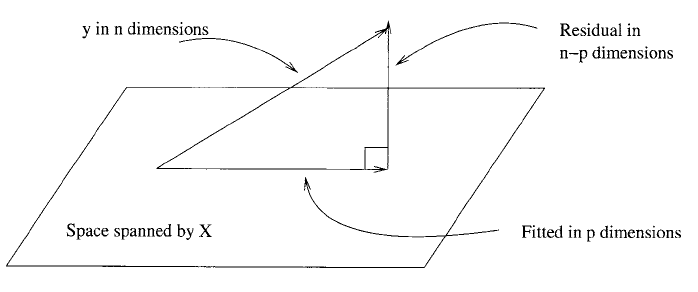

Geometric interpretation of least squares.

$$Data = \text{Systematic Structure} + \text{Random Variation}$$
$$\text{n dimentions} = \text{p dimentions} + \text{(n-p) dimentions}$$

## Goodness of Fit

$R^2$, coefficient of determination or percentage of variance explained, may be used as a measure of goodness of fit.

$$R^2 = 1 - \frac{\sum (\hat{y_i} - y_i)^2}{\sum (y_i - \bar{y})^2} = 1 - \frac{RSS}{TSS}$$

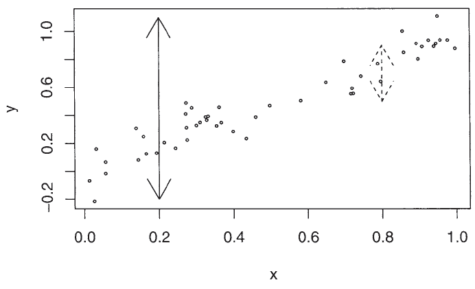

Variation in y conditioned on knowing X vs not knowing X

### Data Analysis exercise:

*gala.csv* description:

| Name | Description |
| --- | --- |
| Species | the number of species of tortoise found on the island |
| Endemics | the number of endemic species |
| Area | the area of the island (km2) |
| Elevation | the highest elevation of the island (m) |
| Nearest | the distance from the nearest island (km) |
| Scruz | the distance from Santa Cruz Island (km) |
| Adjacent | the area of the adjacent island (km2). |

1. Do some basic EDA. What associations seem important?
2. Fit a linear model containing all variables using the lm(Species ~ .) function. What can you say about different coefficients and the goodness of fit?
3. Compute the fitted values, the residuals, RSS and TSS.
4. Compute R-squared and compare with the results to the R-squared computed by the lm().

*Solution,*

```r
gala <- read.table("gala.csv", header = TRUE, row.names = 1, sep = ",")
summary(gala)
```

```
##     Species          Endemics          Area            Elevation
##  Min.   :  2.00   Min.   : 0.00   Min.   :   0.010   Min.   :  25.00
##  1st Qu.: 13.00   1st Qu.: 7.25   1st Qu.:   0.258   1st Qu.:  97.75
##  Median : 42.00   Median :18.00   Median :   2.590   Median : 192.00
##  Mean   : 85.23   Mean   :26.10   Mean   : 261.709   Mean   : 368.03
##  3rd Qu.: 96.00   3rd Qu.:32.25   3rd Qu.:  59.237   3rd Qu.: 435.25
##  Max.   :444.00   Max.   :95.00   Max.   :4669.320   Max.   :1707.00
##     Nearest          Scruz           Adjacent
##  Min.   : 0.20   Min.   :  0.00   Min.   :   0.03
##  1st Qu.: 0.80   1st Qu.: 11.03   1st Qu.:   0.52
##  Median : 3.05   Median : 46.65   Median :   2.59
##  Mean   :10.06   Mean   : 56.98   Mean   : 261.10
##  3rd Qu.:10.03   3rd Qu.: 81.08   3rd Qu.:  59.24
##  Max.   :47.40   Max.   :290.20   Max.   :4669.32
```

```r
cor(gala)
```

```
##               Species     Endemics       Area   Elevation      Nearest
## Species    1.00000000  0.970876516  0.6178431  0.73848666 -0.014094067
## Endemics   0.97087652  1.000000000  0.6169791  0.79290437  0.005994286
## Area       0.61784307  0.616979087  1.0000000  0.75373492 -0.111103196
## Elevation  0.73848666  0.792904369  0.7537349  1.00000000 -0.011076984
## Nearest   -0.01409407  0.005994286 -0.1111032 -0.01107698  1.000000000
## Scruz     -0.17114244 -0.154264319 -0.1007849 -0.01543829  0.615410357
## Adjacent   0.02616635  0.082658026  0.1800376  0.53645782 -0.116247885
##                 Scruz    Adjacent
## Species   -0.17114244  0.02616635
## Endemics  -0.15426432  0.08265803
## Area      -0.10078493  0.18003759
## Elevation -0.01543829  0.53645782
## Nearest    0.61541036 -0.11624788
## Scruz      1.00000000  0.05166066
## Adjacent   0.05166066  1.00000000
```

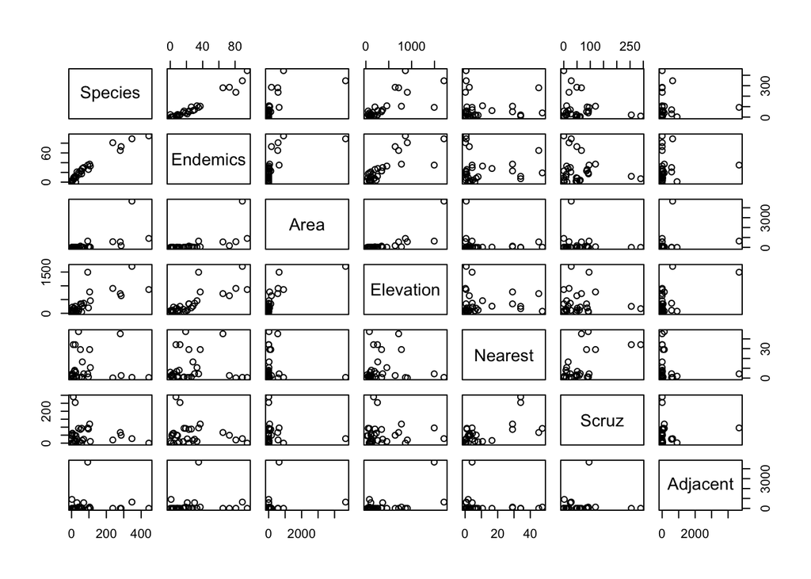

```r
pairs(gala)
```

b.

```r
mdl <- lm(Species ~ Area + Elevation + Nearest + Scruz + Adjacent, data=gala)
summary(mdl)
```

```
##
## Call:
## lm(formula = Species ~ Area + Elevation + Nearest + Scruz + Adjacent,
##     data = gala)
##
## Residuals:
##      Min       1Q   Median       3Q      Max
## -111.679  -34.898   -7.862   33.460  182.584
##
## Coefficients:
##              Estimate Std. Error t value Pr(>|t|)
## (Intercept)  7.068221  19.154198   0.369 0.715351
## Area        -0.023938   0.022422  -1.068 0.296318
## Elevation    0.319465   0.053663   5.953 3.82e-06 ***
## Nearest      0.009144   1.054136   0.009 0.993151
## Scruz       -0.240524   0.215402  -1.117 0.275208
## Adjacent    -0.074805   0.017700  -4.226 0.000297 ***
## ---
## Signif. codes:  0 '***' 0.001 '**' 0.01 '*' 0.05 '.' 0.1 ' ' 1
##
## Residual standard error: 60.98 on 24 degrees of freedom
## Multiple R-squared:  0.7658, Adjusted R-squared:  0.7171
## F-statistic:  15.7 on 5 and 24 DF,  p-value: 6.838e-07
```

```r
RSS <- sum(mdl$residuals^2)
RSS
```

```
## [1] 89231.37
```

```r
TSS <- sum((gala$Species - mean(gala$Species))^2)
TSS
```

```
## [1] 381081.4
```

```r
Rsq <- 1 - RSS/TSS
Rsq
```

```
## [1] 0.7658469
```

# Transformations

Transformations of the response and predictors can improve the fit and correct violations of the model assumptions e.g. nonconstant error variance. We also can add function of multiple predictors. Can you think of some common ones?

Read in savings dataset:

```r
savings <- read.table("savings.csv", header = TRUE,
                      stringsAsFactors = FALSE, sep = ",")
```

## Transforming the Predictors

1. Box-Cox for each predictor.
2. $x \rightarrow f(x)$ and look at the partial residual plots which provides more flexibility.

### Broken Stick Regression

Sometimes we believe that different linear regression models apply in different regions of the data. Let’s examine the *savings* dataset:

Now go ahead and read in this dataset. For this exercise we will only focus on the relationship between *sr* and *pop15*.

1. Fit a regression line to a subset of the data with $pop15 < 35$ and $pop15 > 35$ separately.
2. Make a scatter plot of the data and plot the fitted lines using *segments()*

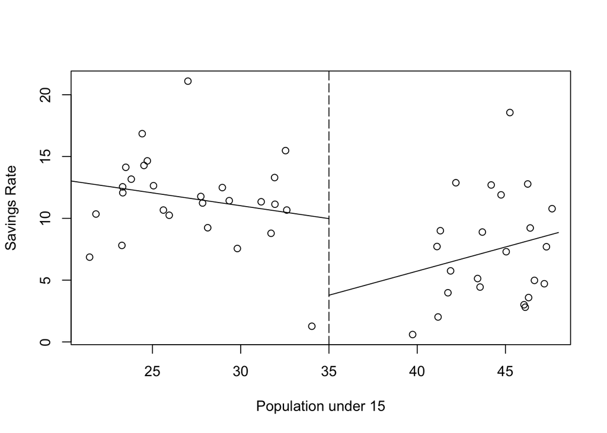

```r
g1 <- lm(sr ~ pop15, savings, subset = (pop15 < 35))
g2 <- lm(sr ~ pop15, savings, subset = (pop15 > 35))
plot(sr ~ pop15, savings, xlab = "Population under 15", ylab = "Savings Rate")
abline(v = 35, lty = 5)
segments(20, g1$coeff[1] + g1$coeff[2]*20, 35, g1$coeff[1] + g1$coeff[2]*35)
segments(35, g2$coeff[1] + g2$coeff[2]*35, 48, g2$coeff[1] + g2$coeff[2]*48)
```

One might have a reason to look for a continuous fit. One can enforce this continuity by introducing new variables:

$$B_l(x) =
\begin{cases}
c - x & x < c \\
0 & otherwise
\end{cases}$$

$$B_r(x) =
\begin{cases}
x - c & x > c \\
0 & otherwise
\end{cases}$$

Where $c$ is the division between the two groups. Now we can fit the following model:

$$y = \beta_0 + \beta_1B_l(x) + \beta_2B_r(x) + \epsilon$$

As an exercise transform the *pop15* variable and fit a linear model to it. Then plot the result.

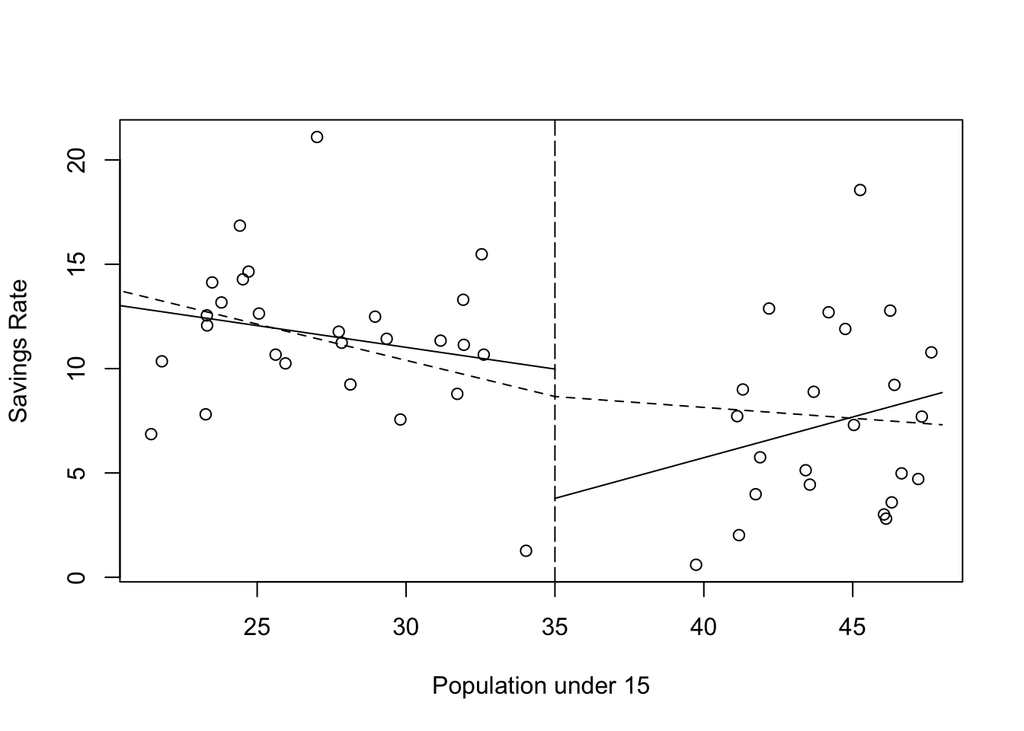

```r
lhs <- function(x) ifelse(x < 35 , 35 - x, 0)
rhs <- function(x) ifelse(x < 35 , 0, x - 35)
gb <- lm(sr ~ lhs(pop15) + rhs(pop15), savings)
x <- seq(20,48,by = 1)
py <- gb$coeff[1] + gb$coeff[2]*lhs(x) + gb$coeff[3]*rhs(x)

plot(sr ~ pop15, savings, xlab = "Population under 15", ylab = "Savings Rate")
abline(v = 35, lty = 5)
segments(20, g1$coeff[1] + g1$coeff[2]*20, 35, g1$coeff[1] + g1$coeff[2]*35)
segments(35, g2$coeff[1] + g2$coeff[2]*35, 48, g2$coeff[1] + g2$coeff[2]*48)

lines(x,py, lty = 2)
```